# 경제자료분석과 예측 (9): 계층 및 그룹 시계열

2025년 2학기

## 계층 및 그룹 시계열

## 1. 서론

시계열 자료는 여러 관심 속성에 따라 자연스럽게 세분화될 수 있다.  
예를 들어 전체 자전거 판매량은 다음과 같이 분해될 수 있다.

- 제품 유형: 로드, MTB, 하이브리드
- 더 세부 분류: 예) 하이브리드 → 도시형, 출퇴근용, 컴포트형, 트래킹형

이러한 세분화는 상위–하위의 **계층적 구조(hierarchical structure)**를 이루며, 이로 인해 생성되는 시계열 집합을 **계층적 시계열(hierarchical time series)**이라 한다.

## 2. 지리적 계층의 예

계층적 시계열은 지리적 분류에서도 흔히 나타난다.

- 국가 → 주(state)
- 주 → 지역(region)
- 지역 → 점포(outlet)

이처럼 점진적으로 세분화되는 구조에서 각 하위 시계열의 합은 상위 시계열을 형성한다.

## 3. 그룹화된(grouped) 시계열

속성이 **중첩(nested)**되지 않고 **교차(crossed)**될 경우 계층 구조가 형성되지 않는다.

예:

- 프레임 크기
- 성별
- 가격대

이 속성들은 서로 독립적이므로 하나의 계층으로 정렬할 수 없다.

이때 생성되는 시계열을 **그룹화된 시계열(grouped time series)**이라 한다.

## 4. 혼합 구조 (Mixed aggregation structures)

때로는 계층 구조(예: 제품 유형)와 그룹 구조(예: 지리적 분류)가 동시에 필요하다.

- 제품 계층 + 지리 계층
- 혼합된(hybrid) 집계 구조

## 5. 일관적(coherent) 예측의 필요성

실무에서는 전체 및 부분 집계된 모든 시계열에 대해 예측이 필요하다.

이때 중요한 점은 예측값들도 **데이터의 집계 방식과 동일하게 합산되어야 한다**는 것이다.

예:

- 지역 예측 → 주 예측으로 합산
- 주 예측 → 국가 예측으로 합산

즉, 전체 계층/그룹 구조에서 **합산 규칙과 충돌하지 않는 예측(coherent forecasts)**이 필요하다.

## 6. 결론

이 장에서는 계층적/그룹화된 구조를 가진 대규모 시계열 집합을 예측하는 방법을 다룬다.

핵심 목표는 **계층·그룹 구조 전체에 대해 합산 규칙을 만족하는(coherent) 예측값을 생성하는 것**이다.

## 계층적(Hierarchical) 시계열

## 1. 계층적 시계열의 구조

계층 구조의 최상단(top level)에는 전체 시계열 **Total**이 위치한다.

Total의 \(t\)번째 관측값은 다음과 같이 표기한다.

\[ y_t \quad (t = 1, \dots, T) \]

Total은 두 개의 시계열로 분해되고, 이 두 시계열은 다시 각각 더 작은 하위 시계열로 분해된다.

## 1. 계층적 시계열의 구조

각 노드(node) \(j\)에 해당하는 시계열의 \(t\)번째 관측값은

\[ y_{j,t} \]

로 표기한다.

예시:

- \(y_{A,t}\): 노드 A의 관측값
- \(y_{AB,t}\): 노드 AB의 관측값

## 2. 예시: 두 단계 계층 구조

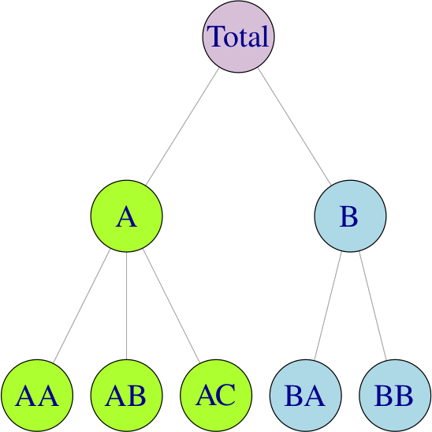

## 2. 예시: 두 단계 계층 구조

### 전체 시계열 개수

\[ n = 1 + 2 + 5 = 8 \]

### 최하위 시계열 개수

\[ m = 5 \]

항상 \(n > m\)임을 확인할 수 있다.

## 3. 계층 구조의 합산 규칙

예:

\[ y_t = y_{AA,t} + y_{AB,t} + y_{AC,t} + y_{BA,t} + y_{BB,t} \tag{11.1} \]

또한 상위 레벨 시리즈는 다음을 만족한다.

\[ y_{A,t} = y_{AA,t} + y_{AB,t} + y_{AC,t} \]

\[ y_{B,t} = y_{BA,t} + y_{BB,t} \tag{11.2} \]

이를 통해 다음이 성립한다.

\[ y_t = y_{A,t} + y_{B,t} \]

## 4. 예시: Australian Tourism Hierarchy

호주는 다음으로 구성된다.

- 6개 주(states)
- 2개 자치령(territories)
- 총 76개의 관광 지역(tourism regions)

관광 산업에서는 다음 단위에 대한 예측이 필요하다.

- 호주 전체
- 주/자치령
- 관광 지역 단위

따라서 전체 계층 구조에서 **일관된(coherent)** 예측이 필수적이다.

## 4. 예시: Australian Tourism Hierarchy

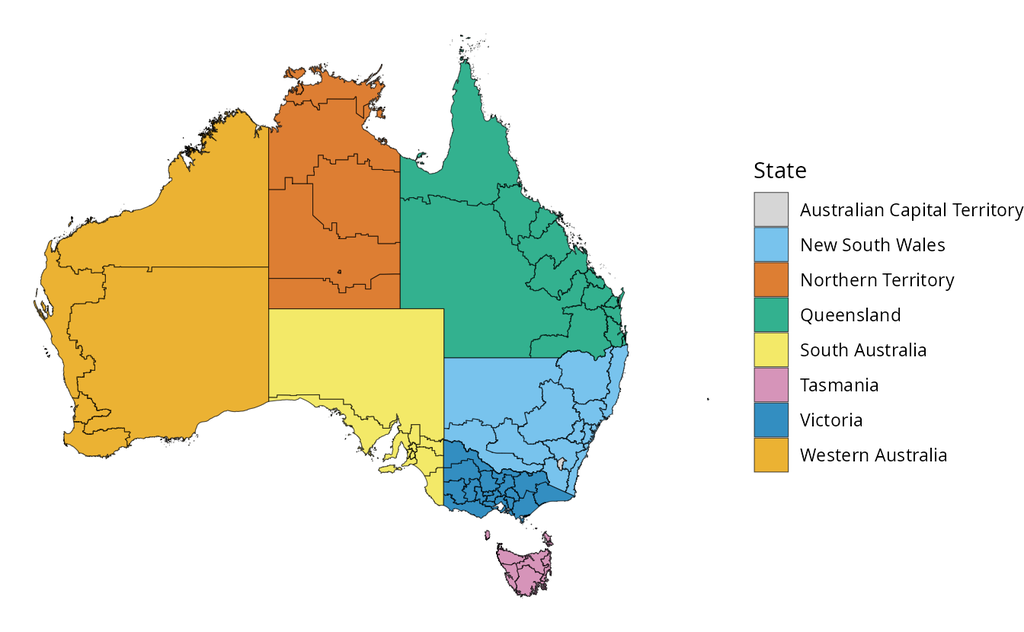

## 5. 관광 지역 데이터

| State | Region |
| --- | --- |
| Australian Capital Territory | Canberra |
| New South Wales | Blue Mountains, Capital Country, Central Coast, Central NSW, Hunter, New England North West, North Coast NSW, Outback NSW, Riverina, Snowy Mountains, South Coast, Sydney, The Murray |
| Northern Territory | Alice Springs, Barkly, Darwin, Kakadu Arnhem, Katherine Daly, Lasseter, MacDonnell |
| Queensland | Brisbane, Bundaberg, Central Queensland, Darling Downs, Fraser Coast, Gold Coast, Mackay, Northern Outback, Sunshine Coast, Tropical North Queensland, Whitsundays |
| South Australia | Adelaide, Adelaide Hills, Barossa, Clare Valley, Eyre Peninsula, Fleurieu Peninsula, Flinders Ranges and Outback, Kangaroo Island, Limestone Coast, Murraylands, Riverland, Yorke Peninsula |
| Tasmania | East Coast, Hobart and the South, Launceston Tamar and the North, North West, Wilderness West |
| Victoria | Ballarat, Bendigo Loddon, Central Highlands, Central Murray, Geelong and the Bellarine, Gippsland, Goulburn, Great Ocean Road, High Country, Lakes, Macedon, Mallee, Melbourne, Melbourne East, Murray E… |
| Western Australia | Australia’s Coral Coast, Australia’s Golden Outback, Australia’s North West, Australia’s South West, Experience Perth |

## 6. 관광 tsibble 구조

tourism tsibble에는 다음 정보가 포함되어 있다.

- 분기별 국내 관광 수요 (overnight trips)
- 주요 변수: `State`, `Region`, `Purpose`
- 여행 목적(Purpose)은 본 절에서 제외하고 계층 구조만 고려한다.

```r
tourism <- tsibble::tourism |>
  mutate(State = recode(State,
    `New South Wales` = "NSW",
    `Northern Territory` = "NT",
    `Queensland` = "QLD",
    `South Australia` = "SA",
    `Tasmania` = "TAS",
    `Victoria` = "VIC",
    `Western Australia` = "WA"
  ))
```

## 7 계층적 시계열 생성: `aggregate_key()`

아래 구조로 계층을 구성한다.

- Bottom: Region
- Middle: State
- Top: Australia (국가 전체)

생성된 tsibble에는 각 분기별로 State 수준과 Australia 수준의 집계 데이터가 포함된다.

## 8. 호주 전체 및 주별 Overnight Trips

호주 전체와 주별 여행 수요는 그림 11.3과 같이 다양한 동학을 보인다.

특징:

- 2010년 이후 상당한 증가 추세
- 여러 주에서 동일한 증가 양상이 관측됨
- Western Australia는 2014년에 급격한 상승

## 9. 호주 전체 및 주별 Overnight Trips

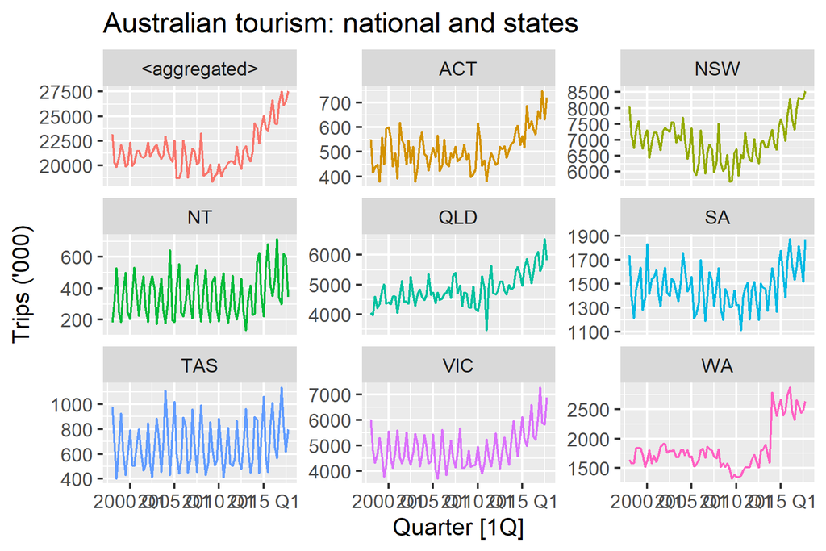

## 10. 계절성 비교

**북부 주(Qld, NT)**

- 겨울(Q3) 정점 (열대 기후)

**남부 주(Vic, Tas)**

- 여름(Q1) 정점 (온대 기후)

## 10. 계절성 비교

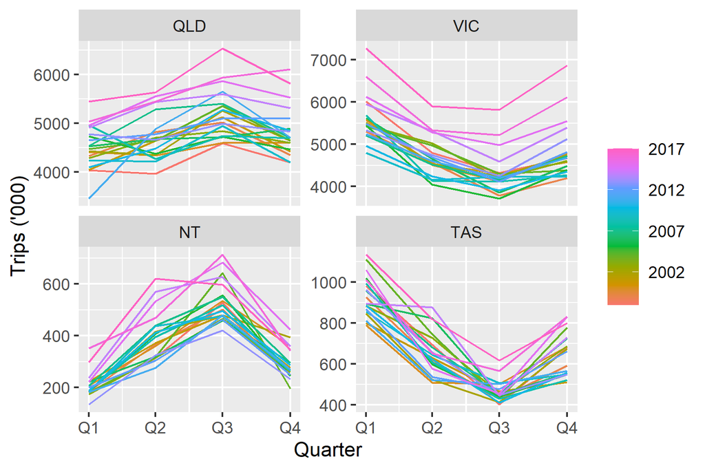

## 11. 지역별 지역 동학

하위 지역(region)의 시계열은 다음 특징을 보인다.

- 강한 추세
- 강한 계절성
- 서로 반대 방향의 계절성
- 노이즈 수준 변동

## 11. 지역별 지역 동학

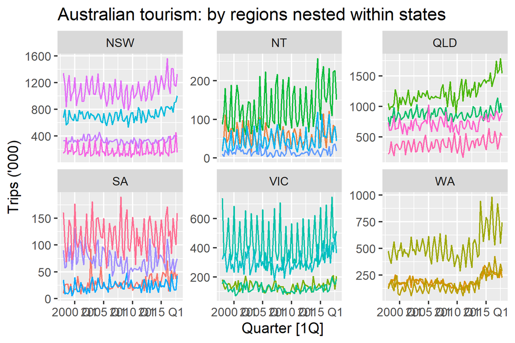

## 12. Grouped Time Series 개념

Grouped time series는 데이터가 **하나의 고유한 계층(hierarchy)** 으로 쪼개지지 않고 여러 속성(attribute)이 **교차(crossed)** 하는 경우에 발생한다.

예:

- 속성 A/B
- 속성 X/Y  
  → 동시에 서로 교차되며 중첩 구조가 아니다.

\[ y_t = y_{AX,t} + y_{AY,t} + y_{BX,t} + y_{BY,t} \]

## 12. Grouped Time Series 개념

속성 A/B 기준:

\[ y_{A,t} = y_{AX,t} + y_{AY,t}, \quad y_{B,t} = y_{BX,t} + y_{BY,t} \tag{11.3} \]

속성 X/Y 기준:

\[ y_{X,t} = y_{AX,t} + y_{BX,t}, \quad y_{Y,t} = y_{AY,t} + y_{BY,t} \tag{11.4} \]

## 13. 예시: 호주 교도소 인구

호주 성인 교도소 인구 자료를 기반으로 한다.

- 상단 패널(top panel): 2005Q1–2016Q4 기간 동안의 호주 전체 수감자 수
- 하단 패널(bottom panels): 다음 속성으로 분해한 수감자 수

세 속성이 교차됨:

- **state**
- **legal status** (sentence vs remand)
- **gender** (Male vs Female)

## 13. 예시: 호주 교도소 인구

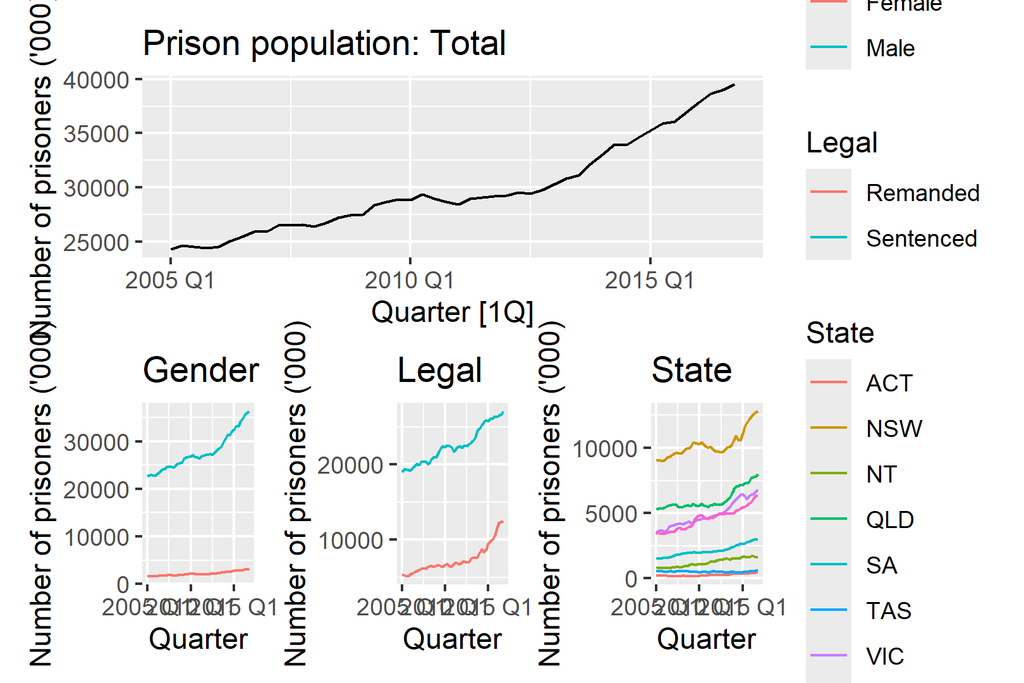

## 13. 예시: 호주 교도소 인구

### Grouped time series 생성 아이디어

- **aggregate_key()**를 이용해 grouped time series를 만든다.
- 이때 관심 있는 속성(또는 그룹)을 **계층(parent/child)**이 아니라 **교차(crossed)** 형태로 지정한다.
- 계층적 시계열에서는 `상위 / 하위` 형식으로 `A / B / C`처럼 parent/child 문법을 쓰지만,
- **grouped time series**에서는 다음과 같이 쓴다.

```r
prison_gts <- prison |>
  aggregate_key(Gender * Legal * State, Count = sum(Count)/1e3)
```

## 13. 예시: 호주 교도소 인구

- filter() 안에서 **is_aggregated()**를 사용하면 grouped 구조에서 어느 수준이 집계(aggregated)되어 있는지를 쉽게 골라낼 수 있다.

예를 들어

- Gender별 총합
- Legal status별 총합
- State별 총합

등을 그리고 싶을 때 유용하다.

## 13. 예시: 호주 교도소 인구

예: Gender만 분해하고, 나머지는 집계 수준으로 유지

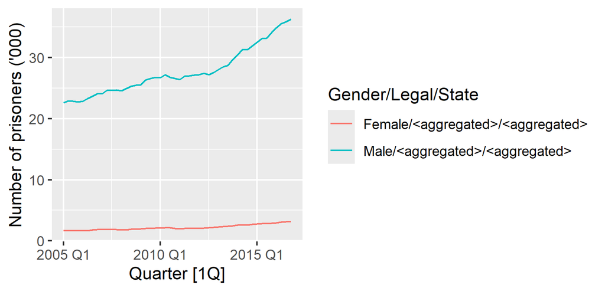

## 13. 예시: 호주 교도소 인구

다른 속성 조합들도 같은 방식으로 그릴 수 있다.

다음 그림에서는 호주 교도소 인구를 두 속성씩 묶어 모든 조합에 대해 보여준다.

- state × gender
- state × legal status
- legal status × gender

## 13. 예시: 호주 교도소 인구

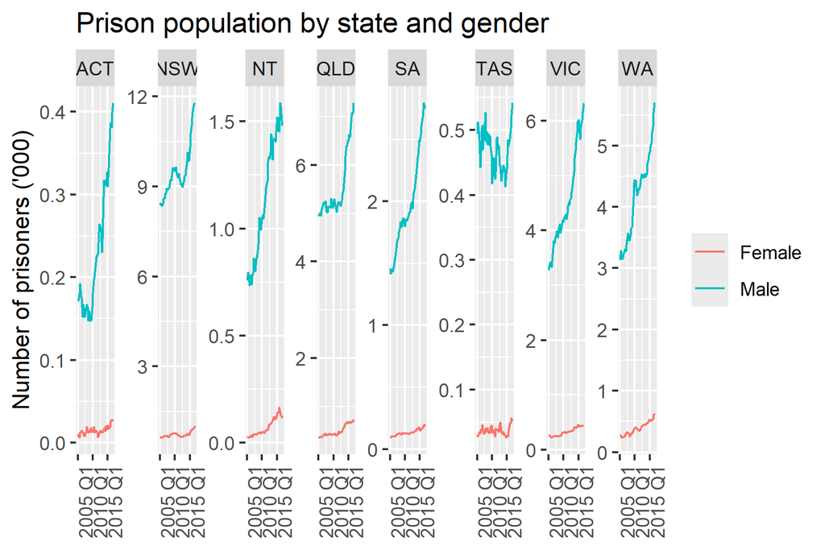

## 13. 예시: 호주 교도소 인구

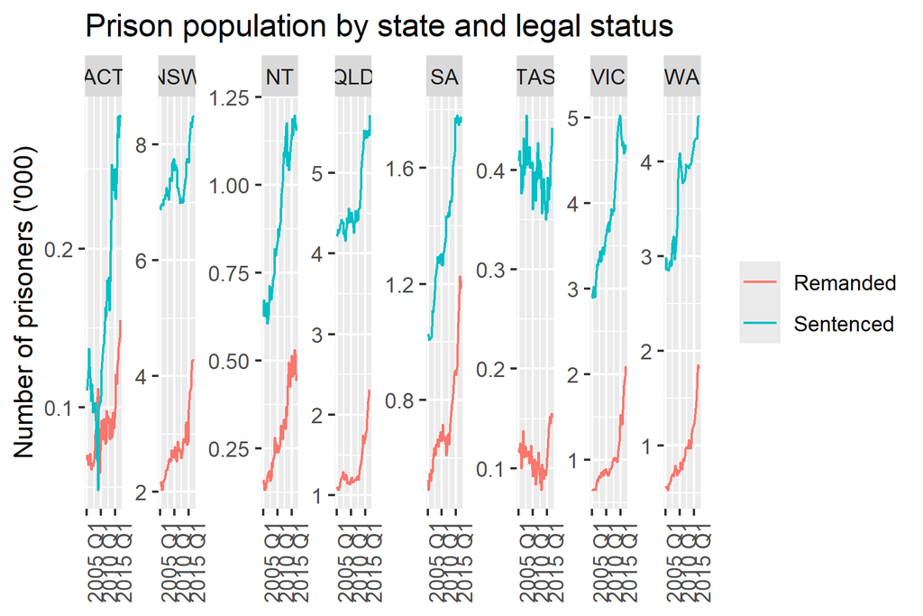

## 13. 예시: 호주 교도소 인구

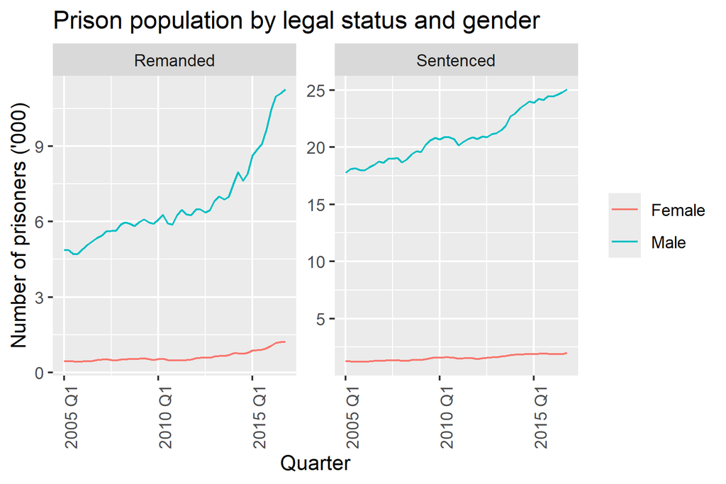

## 13. 예시: 호주 교도소 인구

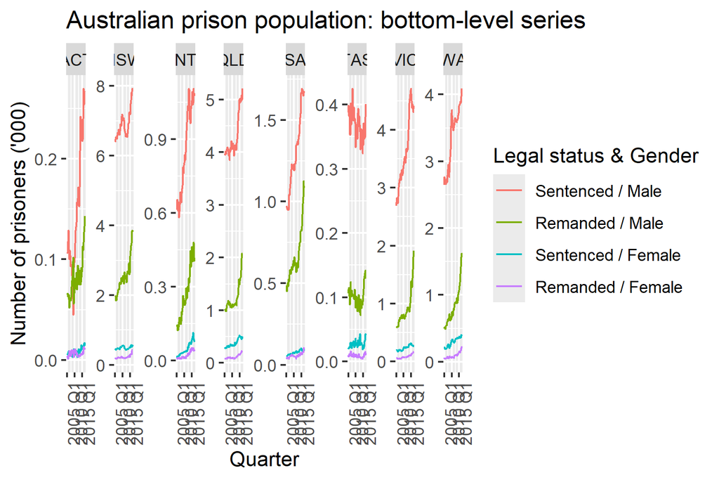

## 14. 혼합된 계층 + 그룹 구조란?

- 실제 데이터에서는 분해 요인들이  
  **계층적(hierarchical, nested)** 이면서 동시에  
  **그룹화(grouped, crossed)** 되는 경우가 많다.
- 예: 호주 관광 데이터(Australian tourism data)
  - 지리적 변수는 **계층 구조**를 이룸
    - Australia → State → Region
  - 동시에, **여행 목적(Purpose)** 으로도 분해 가능
    - Holiday, Business, Visiting friends & relatives, Other
- 여행 목적 변수는 어떤 지리적 변수에도 **포함(nested)** 되어 있지 않다.
  - 즉, **지리 계층(nested geography)** 과  
    **여행 목적(purpose)** 이 **서로 교차(crossed)** 하는 구조

## 15. 구조 설명

- 호주 전체에 대해:
  - Purpose별 overnight trips (Holiday, Business, VFR, Other)
- 각 State에 대해:
  - State × Purpose 조합별 overnight trips
- 각 Region에 대해:
  - Region × Purpose 조합별 overnight trips
- 이 전체 구조를
  - **“지리적 계층(geographic hierarchy)이 Purpose와 교차된 구조”**  
    라고 부른다.

## 15. 구조 설명

- `aggregate_key()`에서는 이런 구조를  
  **요인들을 단순히 결합해서 지정**해 줄 수 있다.

```r
tourism_full <- tourism |>
  aggregate_key((State/Region) * Purpose, Trips = sum(Trips))
```

- `Australia / State / Region`  
  → **중첩된 지리 계층(hierarchical)**
- `* Purpose`  
  → 지리 계층과 **교차된(grouped) 여행 목적**

## 15. 예제: 호주 관광

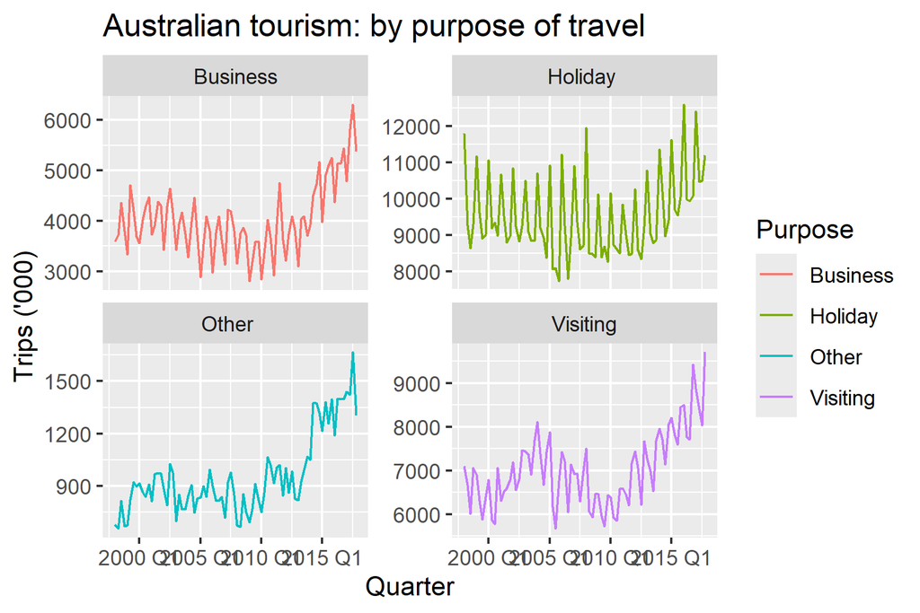

## 15. 예제: 호주 관광

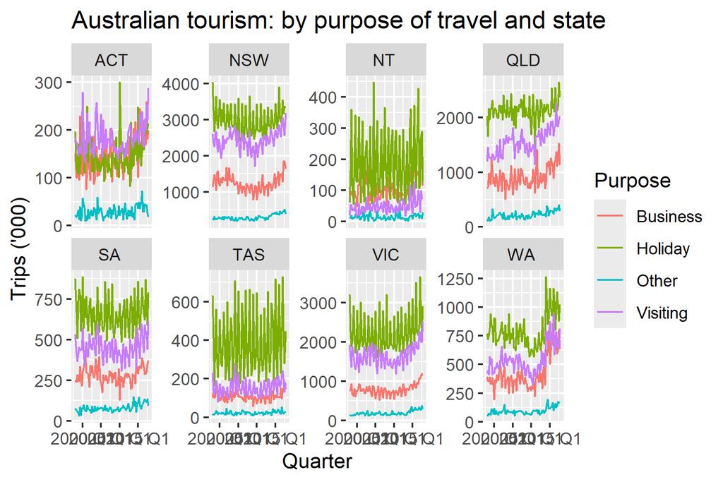

## 16. 시리즈 개수 해석

- `tourism_full` tsibble에는 총 **425개 시계열**이 포함된다.
  - 이 중 **85개**는 순수 **계층 구조(hierarchical)** 에서 나온 시계열
  - 나머지 **340개**는
    - 각 계층 시계열을 **Purpose(4가지)** 로 교차시켜 얻은 시계열
    - 즉, *지리 계층 × Purpose* 조합으로 확장된 구조
- 혼합된 계층·그룹 구조에서는
  - **계층 예측(coherent hierarchical forecasts)** 과
  - **그룹 예측(grouped forecasts)** 을 함께 고려해야 한다.

## 단일 수준 접근법

## 전통적인 계층·그룹 시계열 예측 방식

- 과거에는 **하나의 집계 수준을 선택한 뒤**, 해당 수준에서 예측을 수행하는 방식이 일반적이었음.
- 선택된 수준에서 만든 예측값은
  - 더 높은 수준으로 **집계(aggregate)** 하거나
  - 더 낮은 수준으로 **분해(disaggregate)** 하여
- 전체 구조에서 **일관된(coherent)** 예측값을 얻도록 구성함.

## Bottom-up 접근법

- 가장 단순한 **coherent forecast** 생성 방법.
- 구조의 **가장 아래(bottom level)** 에 있는 모든 시계열을 먼저 예측한 뒤  
  → 이를 **단순 합(sum)** 하여 상위 수준 예측을 생성하는 방식.

## Bottom-up: 예시

예를 들어, Figure 11.1의 계층 구조에서 bottom-level 시계열은 다음과 같음:

- \(\hat{y}_{AA,h}\)
- \(\hat{y}_{AB,h}\)
- \(\hat{y}_{AC,h}\)
- \(\hat{y}_{BA,h}\)
- \(\hat{y}_{BB,h}\)

(여기서 \(\hat{y}_{T+h|T}\) 표기는 단순화를 위해 \(\hat{y}_{\cdot,h}\)로 표현함.)

## Bottom-up: 상위 레벨 coherent 예측 생성

bottom-level 예측값을 합하면 다음처럼 계층 전체에 대해 **coherent forecast**를 얻을 수 있음.

- 전체 계층 합계  
  \[ \tilde{y}_h = \hat{y}_{AA,h} + \hat{y}_{AB,h} + \hat{y}_{AC,h} + \hat{y}_{BA,h} + \hat{y}_{BB,h}. \]
- A 노드  
  \[ \tilde{y}_{A,h} = \hat{y}_{AA,h} + \hat{y}_{AB,h} + \hat{y}_{AC,h}. \]
- B 노드  
  \[ \tilde{y}_{B,h} = \hat{y}_{BA,h} + \hat{y}_{BB,h}. \]

여기서 **틸드(~)** 는 **coherent forecast**임을 의미함.

## Bottom-up 접근법의 장단점

### ✔ 장점

- **정보 손실이 없음**  
  → 가장 세부(bottom-level) 데이터를 사용해 예측하므로 상위 수준에서의 집계로 인해 정보가 사라지는 문제가 없음.

### ✘ 단점

- bottom-level 데이터는 **노이즈가 심하고 변동성이 큼**  
  → 모델링과 예측이 더 어려울 수 있음.

## Bottom-up 접근법의 예제

- 호주의 관광업의 전국 및 지역별 데이터를 모두 가지고 있지만, 지역별 데이터보다 전국 혹시 시도별 단위의 관광업 현황만 관심이 있다고 하자.

```r
tourism_states <- tourism |>
  aggregate_key(State, Trips = sum(Trips))
```

## Bottom-up 접근법의 예제

```r
fcasts_state <- tourism_states |>
  filter(!is_aggregated(State)) |>
  model(arIma = ARIMA(Trips)) |>
  forecast()

# Sum bottom-level forecasts to get top-level forecasts
fcasts_national <- fcasts_state |>
  summarise(value = sum(Trips), .mean = mean(value))
```

## 왜 `reconcile()`이 필요한가?

- Bottom-up 예측은 단순하고 직관적이지만, **모든 상황에서 항상 최적은 아님**.
- 본 장에서 다룰 여러 예측 방법(ARIMA, 회귀모형 등)을 **모두 동일한 방식으로 coherent forecast**로 변환하려면 더 일반적인 프레임워크가 필요하다.

### ✔ 그래서 사용하는 것: `reconcile()`

- `forecast()`로 생성된 예측을 **계층·그룹 구조에 맞게 조정(reconcile)** 하는 단계
- 어떤 방식으로 coherent forecast를 만들지 `reconcile()` 에 명시적으로 지정할 수 있음.

```r
tourism_states |>
  model(arIma = ARIMA(Trips)) |>
  reconcile(bu = bottom_up(arIma)) |>
  forecast()
```

## `reconcile()`의 역할

- `reconcile()`을 적용하면 **coherent forecast를 생성하는 새로운 “모델”** 이 만들어진다.
- 예를 들어 bottom-up 방식을 지정하면:
  - bottom-level에서 예측값 생성
  - 이를 구조에 맞게 집계하여 상위 레벨의 coherent forecast를 생성하는 모델이 구성됨

## `reconcile()` 적용 결과

- 생성된 fable 객체에는:
  - **`ARIMA` 예측**
  - **coherent bottom-up 예측(bu)** 이 *함께* 포함됨.
- 해당 fable 객체는:
  - **8개 주(state)**
  - **국가 전체(total)**  
    에 대한 예측값 포함

## `reconcile()` 적용 결과

### ✔ state 수준에서는?

- `ARIMA` 예측과 bottom-up 예측이 **동일**

### ✔ national(국가 전체) 수준에서는?

- `ARIMA` 예측 vs bottom-up 예측이 **서로 다름**  
  → bottom-up은 하위 시리즈를 전부 합산하는 방식이므로 `ARIMA`처럼 직접 모형화한 상위 수준 결과와 달라질 수 있음.

## Bottom-up에서의 비효율성

- bottom-up 접근에서 `reconcile()`은 약간 비효율적일 수 있음.
  - 우리는 **국가 전체 `ARIMA` 예측** 자체엔 별 관심이 없다(고 가정)
  - 하지만 coherent forecast를 구성하려면 **모든 레벨의 모델을 fable에 포함**해야 함.
  - 그 결과 fable 객체에 **중복되는 모델·예측값이 많아짐**.

## 왜 그래도 `reconcile()`을 써야 할까?

- 이후 나올 **더 발전된 방법들(MinT, OLS reconciliation 등)** 은 모든 aggregation 레벨의 모델을 필요로 함.
- 이 방법들에서는:
  - coherent forecast가 **어느 개별 예측값과도 동일하지 않음**  
    → 독립적인 상향/하향 예측이 아니라 **모든 계층을 동시에 최적화하는 방식**

### ✔ 따라서

`reconcile()`은 단순한 bottom-up을 넘어서 **모든 계층·그룹 시계열을 통합적으로 예측하는 핵심 도구**임.

## 예측을 위한 전체 워크플로우

## 전체 프로세스 요약

1. **`tsibble` 준비** (bottom-level 데이터)
2. **`aggregate_key()`** 로 집계 구조 생성
3. **`model()`** 로 모든 레벨 모델 적합
4. **`reconcile()`** 로 coherent 방식 지정
5. **`forecast()`** 로 전체 구조 예측 생성

```r
data |> aggregate_key() |> model() |>
  reconcile() |> forecast()
```

## 1. Bottom-level tsibble 준비

- 먼저, **각 bottom-level 시계열**이 들어 있는 `tsibble` 객체를 준비한다.
- 예: `data`, `tourism`, `prison` 등
- 이 단계에서는 **순수한 원본 시계열**이 포함되어 있어야 한다.

## 2. `aggregate_key()`로 집계 구조 정의

- `aggregate_key()`를 사용해 **계층 또는 그룹 구조를 명시**한다.
- 이를 통해
  - bottom-level 시리즈
  - 모든 상위 레벨(aggregate level) 시리즈를 모두 포함하는 **확장된 tsibble**이 생성된다.

## 3. `model()`: 모든 레벨에서 모델 추정

- `model()` 함수로  
  **각 집계 수준(level of aggregation)마다 모델을 적합**한다.
- 예:
  - ETS
  - ARIMA
  - Regression
  - 기타 forecast 모델
- 모든 시리즈가 모델을 가져야 이후 단계에서 coherent forecast 생성이 가능하다.

## 4. `reconcile()`: 일관된 예측 생성 방법 지정

- `reconcile()`에서  
  **coherent forecast를 어떻게 만들지** 지정한다.
- 예:
  - `bottom_up()`
  - `top_down()`
  - `middle_out()`
  - `mint_shrink()` (MinT 방식)
- 이 단계에서 *모델 기반 예측값 → 구조적 제약에 맞춘 일관된 예측값*으로 변환된다.

## 5. `forecast()`: 전체 집계 구조에 대한 예측 산출

- 마지막으로 `forecast()`를 호출하면 **계층·그룹 전체 구조에 대한 예측(h-step ahead forecast)** 이 생성된다.
- 이 때 결과물은 coherent forecast가 되어 구조의 합계 관계를 자동으로 만족한다.

## Top-Down 접근법

- Top-down 접근법은 먼저 **최상위 총계(total) 시계열** \(y_t\) 에 대한 예측을 생성한 뒤,
- 이 예측을 **계층 아래로(disaggregation)** 분배하여 하위 시계열의 예측을 구하는 방식이다.

## 분해 비율(disaggregation proportions)

- 총계 예측을 bottom-level 시리즈로 배분하기 위해 \(p_1, \dots, p_m\) 의 **분해 비율**을 설정한다.
- Figure 11.1 구조에서 bottom-level이 5개라면:

\[ \tilde{y}_{AA,t} = p_1 \hat{y}_t,\quad \tilde{y}_{AB,t} = p_2 \hat{y}_t,\quad \tilde{y}_{AC,t} = p_3 \hat{y}_t, \] \[ \tilde{y}_{BA,t} = p_4 \hat{y}_t,\quad \tilde{y}_{BB,t} = p_5 \hat{y}_t. \]

- 이렇게 bottom-level 예측을 만들고, 이를 다시 합산하면 전체 계층에 대해  
  **coherent forecast**를 얻을 수 있다.

## top_down()을 이용한 Top-down 예측

- `reconcile()` 안에서  
  `top_down()` 을 지정하여 Top-down coherent forecast 생성 가능:

## Average historical proportions (과거 비율의 평균)

- 분해 비율 \(p_j\) 를 다음과 같이 정의:

\[ p_j = \frac{1}{T}\sum_{t=1}^{T} \frac{y_{j,t}}{y_t},\qquad j=1,\dots,m. \]

- 이 비율은 기간 \(t=1,\dots,T\) 동안  
  bottom-level 시리즈 \(y_{j,t}\) 가  
  전체 \(y_t\) 에서 차지하는 **비율의 평균값**을 의미한다.

### ✔ fable 구현

```r
top_down(method = "average_proportions")
```

## Proportions of the Historical Averages (과거 평균의 비율)

- 또 다른 Top-down 분해 비율 정의는 다음과 같다.

\[ p_j = \frac{ \frac{1}{T}\sum_{t=1}^{T} y_{j,t} }{ \frac{1}{T}\sum_{t=1}^{T} y_t }, \qquad j = 1, \dots, m. \]

## Proportions of the Historical Averages (과거 평균의 비율)

- \(p_j\) 는 다음을 의미한다:
  - bottom-level 시리즈 \(y_{j,t}\) 의 **평균값**을
  - total 시리즈 \(y_t\) 의 **평균값**으로 나눈 비율
- 즉, 기간 전체에서 **평균적인 상대 규모(average relative size)** 를 반영하는 분해 방식이다.

### fable 구현

```r
top_down(method = "proportion_averages")
```

## Forecast proportions (예측 비율 기반 접근법)

- 역사적 비율을 사용하는 기존 Top-down 방법은 **시간에 따라 비율이 변할 수 있음**을 반영하지 못한다.
- 그 결과 bottom-level 예측 정확도가 **bottom-up 방식보다 낮아지는 경향**이 있다.
- 이를 해결하기 위해 **과거 데이터가 아니라 예측값을 기반으로 한 비율**을 사용한다.  
  → Athanasopoulos et al. (2009)

## Forecast proportions: 기본 아이디어

- 단일 레벨(one-level) 계층을 먼저 생각하자.
1. 모든 시리즈에 대해 **h-step 초기 예측(initial forecasts)** 생성
   - 이 예측들은 coherent하지 않음 (합이 맞지 않음).
2. bottom-level 시리즈의 **예측 비율** 계산  
   \[ p_j = \frac{\hat{y}_{j,h}} {\sum_{k=1}^m \hat{y}_{k,h}} \]
3. top-level의 h-step 예측을  
   이 비율로 배분하여 coherent forecast를 얻음.

## K-레벨 계층에서의 일반 규칙

K 레벨 계층 구조에서는 **각 노드를 위에서 아래로 내려가며 반복 적용**한다.

- bottom-level 시리즈 \(j\) 에 대한 예측 비율은:

\[ p_j = \prod_{\ell=0}^{K-1} \frac{ \hat{y}^{(\ell)}_{j,h} }{ \hat{S}^{(\ell+1)}_{j,h} }. \]

## 기호 설명

- \(\hat{y}^{(\ell)}_{j,h}\):  
  j 시리즈에서 **위로 ℓ 단계 위에 있는 노드**의 h-step 초기 예측
- \(\hat{S}^{(\ell)}_{j,h}\):  
  j 시리즈에서 **위로 ℓ 단계 위 노드의 직계 하위 노드들**에 대한 h-step 초기 예측들의 합
- 이 비율들은 top-level 초기 예측을 bottom-level coherent forecast로 분해하는 데 사용된다.

## 예: Figure 11.1 계층 구조

초기 예측이 주어져 있다고 하자.  
- 최상위 Total 시리즈는 항상  
\[ \tilde{y}_h = \hat{y}_h. \]

- 예시: \[ \hat{y}^{(1)}_{A,h} = \hat{y}^{(1)}_{B,h} = \hat{y}_h = \tilde{y}_h, \]

  \[ \hat{y}^{(1)}_{AA,h} = \hat{y}^{(1)}_{AB,h} = \hat{y}^{(1)}_{AC,h} = \hat{y}_{A,h}. \]

  \[ \hat{y}^{(2)}_{AA,h} = \dots = \hat{y}_h. \]

## 예: Figure 11.1에서의 분해 합 계산

\[ \hat{S}^{(1)}_{AA,h} = \hat{y}_{AA,h} + \hat{y}_{AB,h} + \hat{y}_{AC,h}, \]

\[ \hat{S}^{(2)}_{AA,h} = \hat{S}^{(1)}_{A,h} = \hat{y}_{A,h}+\hat{y}_{B,h}. \]

하향(left-most branch)을 따라 coherent forecast는 다음과 같다.

\[ \tilde{y}_{A,h} = \left( \frac{\hat{y}_{A,h}} {\hat{S}^{(1)}_{A,h}} \right) \tilde{y}_h \]

\[ \tilde{y}_{AA,h} = \left( \frac{\hat{y}_{AA,h}} {\hat{S}^{(1)}_{AA,h}} \right) \tilde{y}_{A,h}. \]

## 예측 비율 p₁ 계산

\[ p_1 = \left( \frac{\hat{y}_{AA,h}} {\hat{S}^{(1)}_{AA,h}} \right) \left( \frac{\hat{y}^{(1)}_{AA,h}} {\hat{S}^{(2)}_{AA,h}} \right). \]

(나머지 비율도 동일한 방식으로 계산됨.)

## fable에서 forecast proportions 적용

```r
reconcile(
  td = top_down(method = "forecast_proportions")
)
```

- `method`를 지정하지 않으면 기본값(default)이 바로 forecast proportions 이다.

## Top-down 접근법의 한계

- Hyndman et al. (2011): Top-down 방식은 편향되지 않은(unbiased) coherent forecast를 만들지 못한다.
- base forecasts가 unbiased여도 top-down으로 조정하면 bias가 생길 수 있음.

## Middle-out Approach (중간-기반 예측 접근법)

- Middle-out 접근법은 **Bottom-up** 과 **Top-down**을 결합한 방식이다.
- 이 방법은 **순수한 계층 구조(hierarchical structure)** 에서만 사용할 수 있다.  
  (Grouped 구조에는 사용 불가)

## Middle-out 접근법의 절차

1. **중간(middle) 수준**을 하나 선택한다.
2. 선택된 중간 수준의 모든 시계열에 대해 **예측을 생성**한다.
3. 중간 수준보다 **위쪽 레벨**(상위 레벨)은
   - 중간 수준 예측을 **합산(bottom-up)** 하여 coherent forecast 생성
4. 중간 수준보다 **아래 레벨**(하위 레벨)은
   - 중간 수준 예측을 **분해(top-down)** 하여 coherent forecast 생성

## 핵심 아이디어

- 중간 레벨을 기준으로
  - 위로는 **bottom-up**,
  - 아래로는 **top-down**  
    방식으로 coherent forecast를 동시에 구현하는 전략
- 중간 레벨의 정보가 가장 믿을 만한 경우 효과적이다.

## fable에서 Middle-out 구현

중간 수준을 `level` 인자로 지정하고, 아래 방향(top-down)에 적용할 방법을 `method` 로 지정한다.

```r
reconcile(
  mo = middle_out(
    model,
    level = "State",                 # 예: 중간 수준
    method = "forecast_proportions"  # top-down 방식 선택
  )
)
```

## 모델 fitting

- 결과물 `fit`은 `tourism_full`의 각 시계열을 `reconcile()`의 세 가지 방법론에 따라 `ARIMA`로 fitting한 결과물임

```r
fc <- fit |> forecast(h = "2 years")
```

- `fit`에 `forecast`를 적용하여 그림까지 생성

```r
fc |>
  filter(is_aggregated(Region), is_aggregated(Purpose)) |>
  autoplot(
    tourism_full |> filter(year(Quarter) >= 2011),
    level = NULL
  ) +
  labs(y = "Trips ('000)") +
  facet_wrap(vars(State), scales = "free_y")
```

## 예측

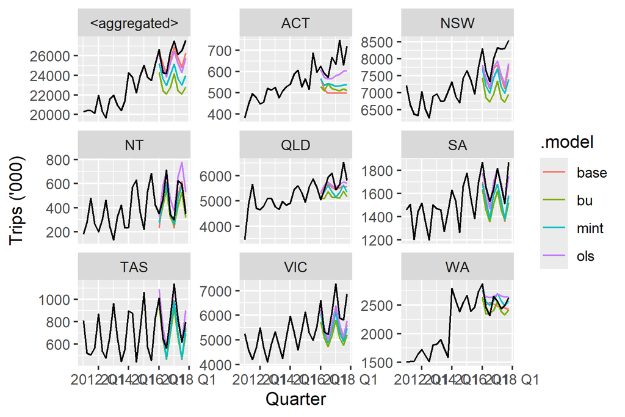

## 예측

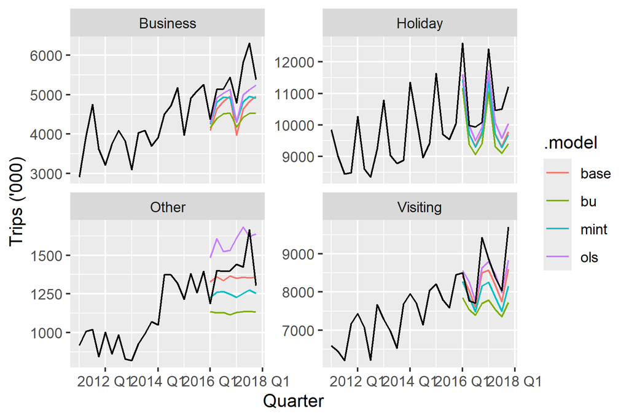

## 예측력 판단: 시각적 비교

- 예측 결과의 차이를 보다 명확히 보기 위해 **훈련 데이터의 마지막 5년만 포함**하고 **예측 구간(PI)은 생략**하였다.
- 대부분의 패널에서 확인할 수 있듯,
  - **테스트 구간(test set)** 후반부의 실제 overnight trips 증가폭이
  - 점추정(point forecasts)보다 **더 큰 경향**이 나타난다.
- 이러한 패턴은 특히 다음 지역에서 두드러진다:
  - ACT
  - New South Wales
  - Queensland
  - Victoria
  - 그리고 **모든 Purpose(여행 목적)** 에서 공통적으로 나타남.

## 검증용 데이터를 통한 예측 정확도 측정

- 예측 정확도는 `accuracy()` 함수로 계산한다.

#### Test set: 2016Q1–2017Q4

| Level | RMSE Base | RMSE Bottom-up | RMSE MinT | RMSE OLS | MASE Base | MASE Bottom-up | MASE MinT | MASE OLS |
| --- | --- | --- | --- | --- | --- | --- | --- | --- |
| Total | 1720.72 | 3071.11 | 2157.55 | 1803.51 | 1.53 | 3.17 | 2.09 | 1.63 |
| Purpose | 533.02 | 802.68 | 586.45 | 513.18 | 1.33 | 2.32 | 1.51 | 1.25 |
| State | 306.85 | 417.21 | 329.74 | 294.66 | 1.40 | 1.88 | 1.45 | 1.27 |
| Regions | 52.64 | 55.13 | 47.40 | 46.95 | 1.13 | 1.18 | 1.02 | 1.00 |
| Bottom | 19.38 | 19.38 | 17.97 | 18.32 | 0.98 | 0.98 | 0.94 | 1.02 |
| All series | 45.96 | 55.28 | 45.61 | 43.19 | 1.04 | 1.08 | 0.98 | 1.03 |

## 해석: 스케일 차이와 오차

- 서로 다른 집계 수준(Top → Bottom)의 시계열은 **규모(scale)가 크게 다르기 때문에**
  - RMSE와 같은 규모 의존(scale-dependent) 오차 지표 비교 시 주의가 필요하다.
- Aggregate(상위) 수준의 RMSE가 커지는 이유:
  - 단순히 **시계열 값 자체가 크기 때문**이다.
- 따라서,
  - 각 집계 수준(level)별로 오차를 비교하고
  - 마지막(bottom row)에서 전체 시리즈 평균을 제시하는 것이 적절하다.

## 예측의 정확성

```r
fc |>
  filter(is_aggregated(State), is_aggregated(Purpose)) |>
  accuracy(
    data = tourism_full,
    measures = list(rmse = RMSE, mase = MASE)
  ) |>
  group_by(.model) |>
  summarise(rmse = mean(rmse), mase = mean(mase))
```

[output not shown]